# 혈색소 수치로 빈혈 예측하는 모델 만들기

## 혈색소 예측

```python
import numpy as np
import pandas as pd

import matplotlib.pyplot as plt
%matplotlib inline
import seaborn as sns

plt.rc('font', family = 'Malgun Gothic')
```

**건강검진 데이터 불러오기**

```python
health = pd.read_csv('health.csv', encoding = 'euc-kr')
```

```python
health.describe(include = "all")
```

|  | 기준년도 | 가입자 일련번호 | 시도코드 | 성별코드 | 연령대 코드(5세단위) | 신장(5Cm단위) | 체중(5Kg 단위) | 허리둘레 | 시력(좌) | 시력(우) | ... | 감마 지티피 | 흡연상태 | 음주여부 | 구강검진 수검여부 | 치아우식증유무 | 결손치 유무 | 치아마모증유무 | 제3대구치(사랑니) 이상 | 치석 | 데이터 공개일자 |
| --- | --- | --- | --- | --- | --- | --- | --- | --- | --- | --- | --- | --- | --- | --- | --- | --- | --- | --- | --- | --- | --- |
| count | 1000000.0 | 1000000.000000 | 1000000.000000 | 1000000.000000 | 1000000.000000 | 1000000.000000 | 1000000.000000 | 999597.000000 | 999805.000000 | 999812.000000 | ... | 994470.000000 | 999834.000000 | 644918.000000 | 1000000.000000 | 397680.000000 | 1000000 | 1000000 | 1000000 | 397680.000000 | 1000000.0 |
| unique | NaN | NaN | NaN | NaN | NaN | NaN | NaN | NaN | NaN | NaN | ... | NaN | NaN | NaN | NaN | NaN | 1 | 1 | 1 | NaN | NaN |
| top | NaN | NaN | NaN | NaN | NaN | NaN | NaN | NaN | NaN | NaN | ... | NaN | NaN | NaN | NaN | NaN | 미시행 | 미시행 | 미시행 | NaN | NaN |
| freq | NaN | NaN | NaN | NaN | NaN | NaN | NaN | NaN | NaN | NaN | ... | NaN | NaN | NaN | NaN | NaN | 1000000 | 1000000 | 1000000 | NaN | NaN |
| mean | 2019.0 | 500000.500000 | 33.712386 | 1.480426 | 10.496387 | 162.307655 | 63.564490 | 81.320565 | 0.971909 | 0.970951 | ... | 36.294294 | 1.369669 | 0.999972 | 0.397680 | 0.210068 | NaN | NaN | NaN | 0.587523 | 20191231.0 |
| std | 0.0 | 288675.278933 | 12.668197 | 0.499617 | 2.964080 | 9.280317 | 12.877611 | 10.523122 | 0.593307 | 0.600537 | ... | 48.390706 | 0.482715 | 0.005283 | 0.489419 | 0.407357 | NaN | NaN | NaN | 0.589261 | 0.0 |
| min | 2019.0 | 1.000000 | 11.000000 | 1.000000 | 5.000000 | 130.000000 | 30.000000 | 3.000000 | 0.100000 | 0.100000 | ... | 1.000000 | 1.000000 | 0.000000 | 0.000000 | 0.000000 | NaN | NaN | NaN | 0.000000 | 20191231.0 |
| 25% | 2019.0 | 250000.750000 | 27.000000 | 1.000000 | 8.000000 | 155.000000 | 55.000000 | 74.000000 | 0.700000 | 0.700000 | ... | 16.000000 | 1.000000 | 1.000000 | 0.000000 | 0.000000 | NaN | NaN | NaN | 0.000000 | 20191231.0 |
| 50% | 2019.0 | 500000.500000 | 41.000000 | 1.000000 | 11.000000 | 160.000000 | 60.000000 | 81.000000 | 1.000000 | 1.000000 | ... | 23.000000 | 1.000000 | 1.000000 | 0.000000 | 0.000000 | NaN | NaN | NaN | 1.000000 | 20191231.0 |
| 75% | 2019.0 | 750000.250000 | 43.000000 | 2.000000 | 13.000000 | 170.000000 | 70.000000 | 88.000000 | 1.200000 | 1.200000 | ... | 39.000000 | 2.000000 | 1.000000 | 1.000000 | 0.000000 | NaN | NaN | NaN | 1.000000 | 20191231.0 |
| max | 2019.0 | 1000000.000000 | 50.000000 | 2.000000 | 18.000000 | 195.000000 | 145.000000 | 999.000000 | 9.900000 | 9.900000 | ... | 999.000000 | 2.000000 | 1.000000 | 1.000000 | 1.000000 | NaN | NaN | NaN | 2.000000 | 20191231.0 |

11 rows × 34 columns

```python
health.head()
```

|  | 기준년도 | 가입자 일련번호 | 시도코드 | 성별코드 | 연령대 코드(5세단위) | 신장(5Cm단위) | 체중(5Kg 단위) | 허리둘레 | 시력(좌) | 시력(우) | ... | 감마 지티피 | 흡연상태 | 음주여부 | 구강검진 수검여부 | 치아우식증유무 | 결손치 유무 | 치아마모증유무 | 제3대구치(사랑니) 이상 | 치석 | 데이터 공개일자 |
| --- | --- | --- | --- | --- | --- | --- | --- | --- | --- | --- | --- | --- | --- | --- | --- | --- | --- | --- | --- | --- | --- |
| 0 | 2019 | 1 | 11 | 1 | 13 | 165 | 65 | 90.0 | 1.5 | 1.2 | ... | 47.0 | 2.0 | NaN | 1 | 0.0 | 미시행 | 미시행 | 미시행 | 1.0 | 20191231 |
| 1 | 2019 | 2 | 48 | 2 | 5 | 155 | 45 | 64.0 | 1.2 | 0.5 | ... | 13.0 | 1.0 | 1.0 | 0 | NaN | 미시행 | 미시행 | 미시행 | NaN | 20191231 |
| 2 | 2019 | 3 | 41 | 1 | 13 | 160 | 70 | 87.0 | 0.9 | 0.8 | ... | 17.0 | 1.0 | 1.0 | 0 | NaN | 미시행 | 미시행 | 미시행 | NaN | 20191231 |
| 3 | 2019 | 4 | 28 | 1 | 12 | 170 | 60 | 85.0 | 0.4 | 1.2 | ... | 32.0 | 2.0 | 1.0 | 0 | NaN | 미시행 | 미시행 | 미시행 | NaN | 20191231 |
| 4 | 2019 | 5 | 41 | 1 | 10 | 170 | 70 | 81.2 | 0.7 | 0.7 | ... | 19.0 | 2.0 | NaN | 0 | NaN | 미시행 | 미시행 | 미시행 | NaN | 20191231 |

5 rows × 34 columns

```python
print(health.columns)
```

```
Index(['기준년도', '가입자 일련번호', '시도코드', '성별코드', '연령대 코드(5세단위)', '신장(5Cm단위)',
       '체중(5Kg 단위)', '허리둘레', '시력(좌)', '시력(우)', '청력(좌)', '청력(우)', '수축기 혈압',
       '이완기 혈압', '식전혈당(공복혈당)', '총 콜레스테롤', '트리글리세라이드', 'HDL 콜레스테롤', 'LDL 콜레스테롤',
       '혈색소', '요단백', '혈청크레아티닌', '(혈청지오티)AST', '(혈청지오티)ALT', '감마 지티피', '흡연상태',
       '음주여부', '구강검진 수검여부', '치아우식증유무', '결손치 유무', '치아마모증유무', '제3대구치(사랑니) 이상',
       '치석', '데이터 공개일자'],
      dtype='object')
```

**불필요한 변수 제거**

```python
health = health.drop(['기준년도'], axis = 1)
health = health.drop(['가입자 일련번호'], axis = 1)
health = health.drop(['시도코드'], axis = 1)
health = health.drop(['총 콜레스테롤'], axis = 1)
health = health.drop(['트리글리세라이드'], axis = 1)
health = health.drop(['HDL 콜레스테롤'], axis = 1)
health = health.drop(['LDL 콜레스테롤'], axis = 1)
health = health.drop(['요단백'], axis = 1)
health = health.drop(['혈청크레아티닌'], axis = 1)
health = health.drop(['(혈청지오티)AST'], axis = 1)
health = health.drop(['(혈청지오티)ALT'], axis = 1)
health = health.drop(['감마 지티피'], axis = 1)
health = health.drop(['구강검진 수검여부'], axis = 1)
health = health.drop(['치아우식증유무'], axis = 1)
health = health.drop(['결손치 유무'], axis = 1)
health = health.drop(['치아마모증유무'], axis = 1)
health = health.drop(['제3대구치(사랑니) 이상'], axis = 1)
health = health.drop(['치석'], axis = 1)
health = health.drop(['데이터 공개일자'], axis = 1)
```

```python
print(health.columns)
```

```
Index(['성별코드', '연령대 코드(5세단위)', '신장(5Cm단위)', '체중(5Kg 단위)', '허리둘레', '시력(좌)',
       '시력(우)', '청력(좌)', '청력(우)', '수축기 혈압', '이완기 혈압', '식전혈당(공복혈당)', '혈색소',
       '흡연상태', '음주여부'],
      dtype='object')
```

```python
health.columns = ['Sex', 'Age', 'Height', 'Weight', 'Waist', 'sight_L',
                  'sight_R','Hear_L', 'Hear_R', 'BP_high', 'BP_lwst',
                 'Blds', 'Hmg', 'SMK', 'DRK']
```

```python
print(health.columns)
```

```
Index(['Sex', 'Age', 'Height', 'Weight', 'Waist', 'sight_L', 'sight_R',
       'Hear_L', 'Hear_R', 'BP_high', 'BP_lwst', 'Blds', 'Hmg', 'SMK', 'DRK'],
      dtype='object')
```

```python
health.head()
#14개의 반응변수
```

|  | Sex | Age | Height | Weight | Waist | sight_L | sight_R | Hear_L | Hear_R | BP_high | BP_lwst | Blds | Hmg | SMK | DRK |
| --- | --- | --- | --- | --- | --- | --- | --- | --- | --- | --- | --- | --- | --- | --- | --- |
| 0 | 1 | 13 | 165 | 65 | 90.0 | 1.5 | 1.2 | 1.0 | 1.0 | 112.0 | 70.0 | 93.0 | 15.5 | 2.0 | NaN |
| 1 | 2 | 5 | 155 | 45 | 64.0 | 1.2 | 0.5 | 1.0 | 1.0 | 114.0 | 76.0 | 89.0 | 14.0 | 1.0 | 1.0 |
| 2 | 1 | 13 | 160 | 70 | 87.0 | 0.9 | 0.8 | 1.0 | 1.0 | 109.0 | 73.0 | 100.0 | 15.6 | 1.0 | 1.0 |
| 3 | 1 | 12 | 170 | 60 | 85.0 | 0.4 | 1.2 | 1.0 | 1.0 | 131.0 | 85.0 | 85.0 | 14.5 | 2.0 | 1.0 |
| 4 | 1 | 10 | 170 | 70 | 81.2 | 0.7 | 0.7 | 1.0 | 1.0 | 112.0 | 66.0 | 91.0 | 14.9 | 2.0 | NaN |

**결측값 확인**

```python
print(pd.isnull(health).sum())
```

```
Sex             0
Age             0
Height          0
Weight          0
Waist         403
sight_L       195
sight_R       188
Hear_L        181
Hear_R        178
BP_high      5424
BP_lwst      5425
Blds         5523
Hmg          5532
SMK           166
DRK        355082
dtype: int64
```

**변수 간 상관관계**

종속변수(Hmg)와 상관관계 있는 것

종속변수(Hmg)와 상관계수

음의 상관계수 : 성별(-0.66)

양의 상관계수 : 신장(0.52), 몸무게(0.49), 흡연여부(0.44)

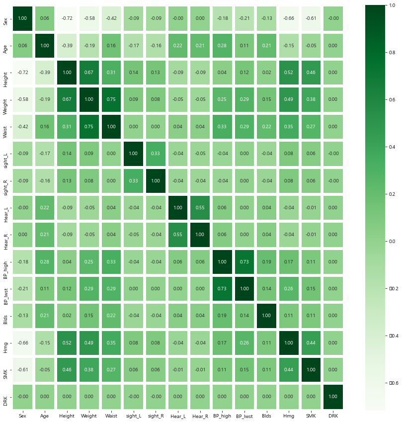

```python
plt.figure(figsize = (15, 15))
sns.heatmap(data = health.corr(), annot = True, fmt = '.2f',
            linewidths = 5, cmap = 'Greens')
```

**EDA**

**종속변수(혈색소)**

결측값이 있는 행 모두 제거

```python
health.dropna(subset=['Hmg'], how='all', inplace=True)
```

```python
print(pd.isnull(health['Hmg']).sum())
```

```
0
```

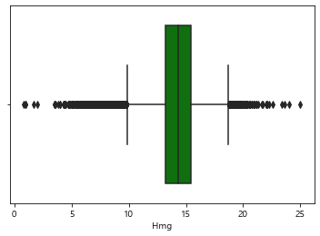

```python
sns.boxplot(health['Hmg'], color = 'green')
plt.show()
```

이상치 제거

```python
health['Hmg'].min()
```

```
0.8
```

```python
health['Hmg'].max()
```

```
25.0
```

혈색소 수치가 7 미만인 경우 삭제

```python
idx_1 = health[health['Hmg'] < 7].index
```

```python
health_1 = health.drop(idx_1)
```

혈색소 수치가 20초과인 경우 삭제

```python
idx_2 = health_1[health_1['Hmg'] > 20].index
```

```python
health_2 = health_1.drop(idx_2)
```

```python
health_2['Hmg']
```

```
0         15.5
1         14.0
2         15.6
3         14.5
4         14.9
          ...
999995    15.7
999996    15.4
999997    15.9
999998    15.3
999999    13.2
Name: Hmg, Length: 993991, dtype: float64
```

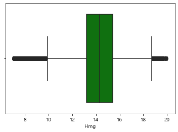

```python
sns.boxplot(health_2['Hmg'], color = 'green')
plt.show()
```

혈색소 수치 7-12 : 낮음, 12-17 : 정상, 17이상 : 과다

```python
bins = [7, 12, 17]

np.digitize(health_2['Hmg'], bins)
health_2['Hmg'] = np.digitize(health_2['Hmg'], bins)
```

```python
health_2['Hmg']
```

```
0         2
1         2
2         2
3         2
4         2
         ..
999995    2
999996    2
999997    2
999998    2
999999    2
Name: Hmg, Length: 993991, dtype: int64
```

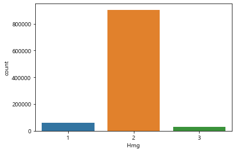

```python
sns.countplot(x = 'Hmg', data = health_2)
```

```python
health_2
```

|  | Sex | Age | Height | Weight | Waist | sight_L | sight_R | Hear_L | Hear_R | BP_high | BP_lwst | Blds | Hmg | SMK | DRK |
| --- | --- | --- | --- | --- | --- | --- | --- | --- | --- | --- | --- | --- | --- | --- | --- |
| 0 | 1 | 13 | 165 | 65 | 90.0 | 1.5 | 1.2 | 1.0 | 1.0 | 112.0 | 70.0 | 93.0 | 2 | 2.0 | NaN |
| 1 | 2 | 5 | 155 | 45 | 64.0 | 1.2 | 0.5 | 1.0 | 1.0 | 114.0 | 76.0 | 89.0 | 2 | 1.0 | 1.0 |
| 2 | 1 | 13 | 160 | 70 | 87.0 | 0.9 | 0.8 | 1.0 | 1.0 | 109.0 | 73.0 | 100.0 | 2 | 1.0 | 1.0 |
| 3 | 1 | 12 | 170 | 60 | 85.0 | 0.4 | 1.2 | 1.0 | 1.0 | 131.0 | 85.0 | 85.0 | 2 | 2.0 | 1.0 |
| 4 | 1 | 10 | 170 | 70 | 81.2 | 0.7 | 0.7 | 1.0 | 1.0 | 112.0 | 66.0 | 91.0 | 2 | 2.0 | NaN |
| ... | ... | ... | ... | ... | ... | ... | ... | ... | ... | ... | ... | ... | ... | ... | ... |
| 999995 | 1 | 12 | 170 | 65 | 80.0 | 1.0 | 1.2 | 1.0 | 1.0 | 116.0 | 79.0 | 129.0 | 2 | 1.0 | 1.0 |
| 999996 | 1 | 9 | 170 | 55 | 75.0 | 0.9 | 0.8 | 1.0 | 1.0 | 99.0 | 61.0 | 130.0 | 2 | 2.0 | 1.0 |
| 999997 | 1 | 13 | 160 | 65 | 92.3 | 1.0 | 0.9 | 1.0 | 1.0 | 116.0 | 70.0 | 102.0 | 2 | 2.0 | 1.0 |
| 999998 | 1 | 8 | 170 | 75 | 85.0 | 0.8 | 0.8 | 1.0 | 1.0 | 112.0 | 71.0 | 89.0 | 2 | 2.0 | 1.0 |
| 999999 | 2 | 10 | 155 | 65 | 86.0 | 0.5 | 0.5 | 1.0 | 1.0 | 118.0 | 73.0 | 67.0 | 2 | 1.0 | NaN |

993991 rows × 15 columns

**독립변수**

성별 변수

여자가 남자에 비해 혈색소 수치가 낮은 경우가 많고, 남자가 여자에 비해 혈색소 수치가 높은 경우가 많다.

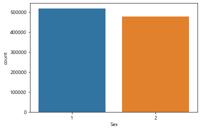

```python
sns.countplot(x = "Sex", data = health_2)
plt.show()
```

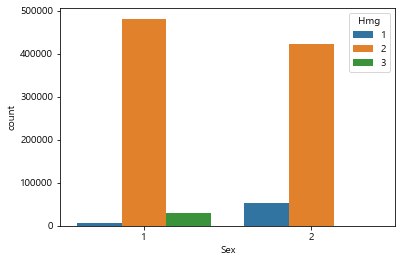

```python
sns.countplot(x = "Sex", data = health_2, hue = "Hmg")
plt.show()
```

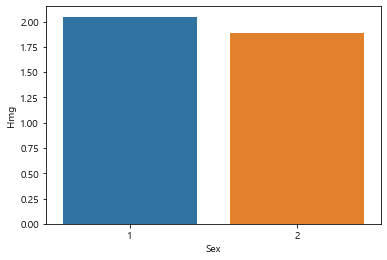

```python
sns.barplot(x = "Sex", y = "Hmg", data = health_2)
plt.show()
```

나이 변수

5 : 20-24세 6 : 25-29세 7 : 30-34세 8 : 35-39세 9 : 40-44세 10 : 45-49세 11 : 50-54세 12 : 55-59세 13 : 60-64세 14 : 65-69세 15 : 70-74세 16 : 75-79세 17 : 80-84세 18 : 85세~

20대 : 1, 30대 : 2, 40대 : 3, 50대 : 4, 60대 : 5, 70대 : 6, 80세 이상 : 7

```python
bins = [5, 7, 9, 11, 13, 15, 17]

np.digitize(health_2['Age'], bins)
health_2['Age'] = np.digitize(health_2['Age'], bins)
```

```python
health['Age']
```

```
0         13
1          5
2         13
3         12
4         10
          ..
999995    12
999996     9
999997    13
999998     8
999999    10
Name: Age, Length: 994468, dtype: int64
```

```python
health_2['Age']
```

```
0         5
1         1
2         5
3         4
4         3
         ..
999995    4
999996    3
999997    5
999998    2
999999    3
Name: Age, Length: 993991, dtype: int64
```

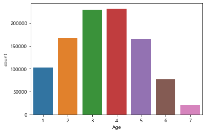

```python
sns.countplot(x = "Age", data = health_2)
plt.show()
```

80세 이상의 경우 비교적 혈색소 수치가 낮지만, 연령에 따른 혈색소 수치의 관계는 없어보인다.

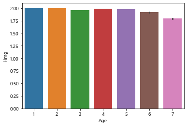

```python
sns.barplot(x = "Age", y = "Hmg", data = health_2)
plt.show()
```

신장

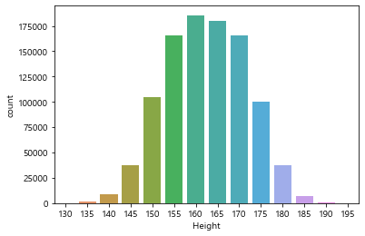

```python
sns.countplot(x = "Height", data = health_2)
plt.show()
```

근소하지만 키가 클수록 혈색소 수치가 높다.

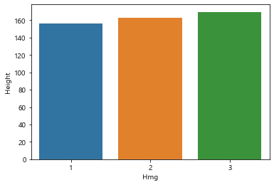

```python
sns.barplot(x = "Hmg", y = "Height", data = health_2)
```

체중

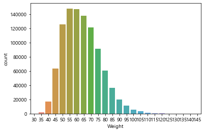

```python
sns.countplot(x = "Weight", data = health_2)
```

체중이 높을수록 혈색소 수치가 높다.

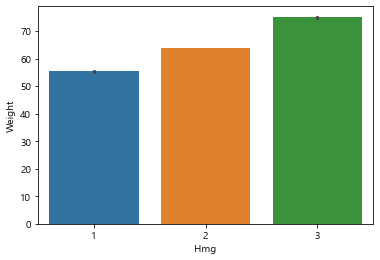

```python
sns.barplot(x = "Hmg", y = "Weight", data = health_2)
plt.show()
```

Weight 변수 범주화

1 : 30-50, 2 : 50-70, 3 : 70-90, 4 : 90-110, 5 : 110-

```python
print(health_2['Weight'].min())
print(health_2['Weight'].max())
```

```
30
145
```

```python
bins = [30, 50, 70, 90, 110]

np.digitize(health_2['Weight'], bins)
health_2['Weight'] = np.digitize(health_2['Weight'], bins)
```

```python
health_2['Weight']
```

```
0         2
1         1
2         3
3         2
4         3
         ..
999995    2
999996    2
999997    2
999998    3
999999    2
Name: Weight, Length: 993991, dtype: int64
```

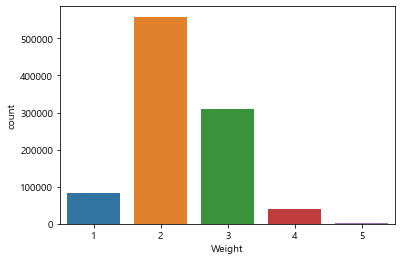

```python
sns.countplot(x = 'Weight', data = health_2)
plt.show()
```

허리둘레

결측치 처리

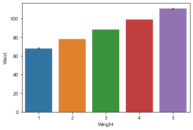

```python
sns.barplot(x = "Weight", y = "Waist", data = health_2)
```

체중 별 허리둘레의 중앙값을 Waist변수의 결측치에 대입한다.

```python
health_2.groupby(['Weight'])['Waist'].median()
```

```
Weight
1     67.0
2     78.0
3     88.0
4     99.0
5    110.0
Name: Waist, dtype: float64
```

```python
health_2["Waist"].fillna(health_2.groupby("Weight")["Waist"].transform("median"),
                  inplace = True)
```

```python
print(pd.isnull(health_2['Waist']).sum())
```

```
0
```

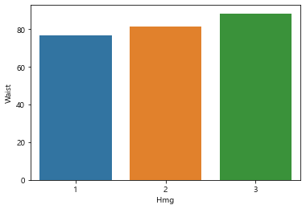

```python
sns.barplot(x = health_2['Hmg'], y = health_2['Waist'])
plt.show()
```

시력(좌)

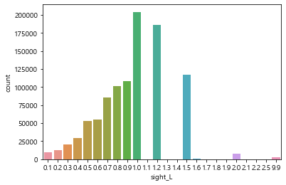

```python
sns.countplot(x = "sight_L", data = health_2)
plt.show()
```

시력은 예측할 수 있는 것이 없어서 좌 시력의 결측치를 지운다.

```python
health_2.dropna(subset=['sight_L'], how='all', inplace=True)
```

```python
print(pd.isnull(health_2['sight_L']).sum())
```

```
0
```

그래프를 봤을 때 9.9의 값은 실명이나 맹인을 뜻하므로 0.0으로 변경해준다.

```python
health_2['sight_L'] = health_2['sight_L'].replace(9.9, 0.0)
```

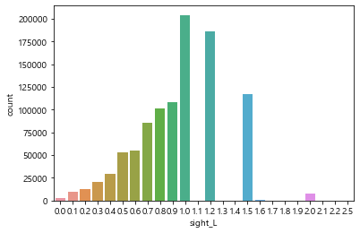

```python
sns.countplot(x = "sight_L", data = health_2)
```

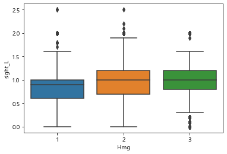

```python
sns.boxplot(x = health_2['Hmg'], y = health_2['sight_L'])
plt.show()
```

시력(우)

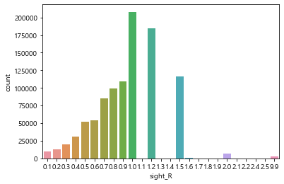

```python
sns.countplot(x = "sight_R", data = health_2)
plt.show()
```

```python
health_2.dropna(subset=['sight_R'], how='all', inplace=True)
```

```python
print(pd.isnull(health_2['sight_R']).sum())
```

```
0
```

```python
health_2['sight_R'] = health_2['sight_R'].replace(9.9, 0.0)
```

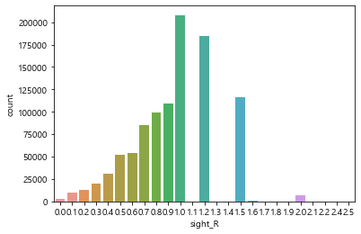

```python
sns.countplot(x = "sight_R", data = health_2)
```

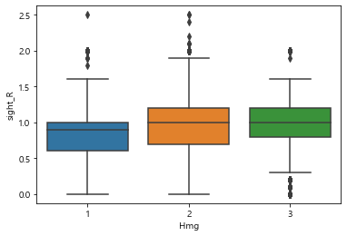

```python
sns.boxplot(x = health_2['Hmg'], y = health_2['sight_R'])
plt.show()
```

청력(좌)

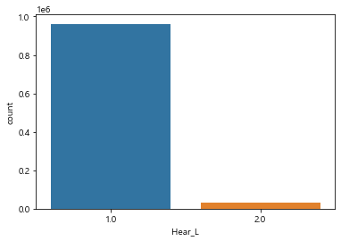

```python
sns.countplot(x = "Hear_L", data = health_2)
plt.show()
```

```python
health_2['Hear_L'] = health_2['Hear_L'].fillna(1.0)
```

```python
print(pd.isnull(health_2['Hear_L']).sum())
```

```
0
```

[figure not shown]

```python
sns.barplot(x = health_2['Hear_L'], y = health_2['Hmg'])
plt.show()
```

청력(우)

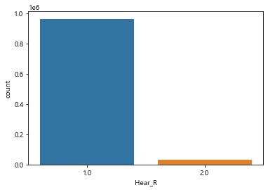

```python
sns.countplot(x = "Hear_R", data = health_2)
```